# Исследование рынка видеоигр

# Описание проекта, необходимых шагов и данных

## Описание проекта

Мы работаем в интернет-магазине «Стримчик», который продаёт по всему миру компьютерные игры. Из открытых источников доступны исторические данные о продажах игр, оценки пользователей и экспертов, жанры и платформы (например, Xbox или PlayStation). Нам нужно выявить определяющие успешность игры закономерности. Это позволит сделать ставку на потенциально популярный продукт и спланировать рекламные кампании.

Перед нами данные до 2016 года. Представим, что сейчас декабрь 2016 г., и мы планируем кампанию на 2017-й. Нужно отработать принцип работы с данными. Неважно, прогнозируем ли мы продажи на 2017 год по данным 2016-го или же 2027-й — по данным 2026 года.

## Необходимые шаги

**Шаг 1.** Открыть файл с данными и изучить общую информацию

**Шаг 2.** Подготовить данные:

- Заменить названия столбцов;
- Преобразовать данные в нужные типы;
- Обработать пропуски при необходимости:
  - Объяснить, почему заполнили пропуски определённым образом или почему не стали это делать;
  - Описать причины, которые могли привести к пропускам;
  - Обратить внимание на аббревиатуру `tbd` в столбце с оценкой пользователей. Отдельно разбить это значение и описать, как его обработать;
- Посчитать суммарные продажи во всех регионах и записать их в отдельный столбец.

**Шаг 3.** Провести исследовательский анализ данных:

- Посмотреть, сколько игр выпускалось в разные годы. Важны ли данные за все периоды?
- Посмотреть, как менялись продажи по платформам. Выбрать платформы с наибольшими суммарными продажами и построить распределение по годам. За какой характерный срок появляются новые и исчезают старые платформы?
- Взять данные за соответствующий актуальный период.
- Какие платформы лидируют по продажам, растут или падают? Выбрать несколько потенциально прибыльных платформ.
- Построить график «ящик с усами» по глобальным продажам игр в разбивке по платформам. Описать результат.
- Посмотреть, как влияют на продажи внутри одной популярной платформы отзывы пользователей и критиков. Построить диаграмму рассеяния и посчитать корреляцию между отзывами и продажами. Сформулировать выводы.
- Соотнести выводы с продажами игр на других платформах.
- Посмотреть на общее распределение игр по жанрам. Что можно сказать о самых прибыльных жанрах? Выделяются ли жанры с высокими и низкими продажами?

**Шаг 4.** Составить портрет пользователя каждого региона. Определить для пользователя каждого региона (NA, EU, JP):

- Самые популярные платформы (топ-5). Описать различия в долях продаж.
- Самые популярные жанры (топ-5). Пояснить разницу.
- Влияет ли рейтинг ESRB на продажи в отдельном регионе?

**Шаг 5.** Проверить гипотезы

- Средние пользовательские рейтинги платформ Xbox One и PC одинаковые;
- Средние пользовательские рейтинги жанров Action (англ. «действие», экшен-игры) и Sports (англ. «спортивные соревнования») разные.

**Шаг 6.** Написать общий вывод

## Описание данных

- `Name` — название игры
- `Platform` — платформа
- `Year_of_Release` — год выпуска
- `Genre` — жанр игры
- `NA_sales` — продажи в Северной Америке (миллионы проданных копий)
- `EU_sales` — продажи в Европе (миллионы проданных копий)
- `JP_sales` — продажи в Японии (миллионы проданных копий)
- `Other_sales` — продажи в других странах (миллионы проданных копий)
- `Critic_Score` — оценка критиков (максимум 100)
- `User_Score` — оценка пользователей (максимум 10)
- `Rating` — рейтинг от организации ESRB (англ. Entertainment Software Rating Board). Эта ассоциация определяет рейтинг компьютерных игр и присваивает им подходящую возрастную категорию.

# Обзор данных

```python
# Импортируем необходимые библиотеки

import pandas as pd
import matplotlib.pyplot as plt
import seaborn as sns
import numpy as np
from scipy import stats as st
```

```python
# Прочитаем датафрейм и запишем в перменную
df = pd.read_csv('games.csv')

# Для удобства отобразим все колонки таблицы
pd.set_option('display.max_columns', None)

# Ознакомимся с первыми и последними 5 строками таблицы
df
```

|  | Name | Platform | Year_of_Release | Genre | NA_sales | EU_sales | JP_sales | Other_sales | Critic_Score | User_Score | Rating |
| --- | --- | --- | --- | --- | --- | --- | --- | --- | --- | --- | --- |
| 0 | Wii Sports | Wii | 2006.0 | Sports | 41.36 | 28.96 | 3.77 | 8.45 | 76.0 | 8 | E |
| 1 | Super Mario Bros. | NES | 1985.0 | Platform | 29.08 | 3.58 | 6.81 | 0.77 | NaN | NaN | NaN |
| 2 | Mario Kart Wii | Wii | 2008.0 | Racing | 15.68 | 12.76 | 3.79 | 3.29 | 82.0 | 8.3 | E |
| 3 | Wii Sports Resort | Wii | 2009.0 | Sports | 15.61 | 10.93 | 3.28 | 2.95 | 80.0 | 8 | E |
| 4 | Pokemon Red/Pokemon Blue | GB | 1996.0 | Role-Playing | 11.27 | 8.89 | 10.22 | 1.00 | NaN | NaN | NaN |
| ... | ... | ... | ... | ... | ... | ... | ... | ... | ... | ... | ... |
| 16710 | Samurai Warriors: Sanada Maru | PS3 | 2016.0 | Action | 0.00 | 0.00 | 0.01 | 0.00 | NaN | NaN | NaN |
| 16711 | LMA Manager 2007 | X360 | 2006.0 | Sports | 0.00 | 0.01 | 0.00 | 0.00 | NaN | NaN | NaN |
| 16712 | Haitaka no Psychedelica | PSV | 2016.0 | Adventure | 0.00 | 0.00 | 0.01 | 0.00 | NaN | NaN | NaN |
| 16713 | Spirits & Spells | GBA | 2003.0 | Platform | 0.01 | 0.00 | 0.00 | 0.00 | NaN | NaN | NaN |
| 16714 | Winning Post 8 2016 | PSV | 2016.0 | Simulation | 0.00 | 0.00 | 0.01 | 0.00 | NaN | NaN | NaN |

16715 rows × 11 columns

*Вывод:* По выведенным строкам видим пропущенные значения, изучим подробней сколько их во всем датафрейме

```python
# Ознакомимся с общей информацией по датафрейму
df.info()
```

```
<class 'pandas.core.frame.DataFrame'>
RangeIndex: 16715 entries, 0 to 16714
Data columns (total 11 columns):
 #   Column           Non-Null Count  Dtype
---  ------           --------------  -----
 0   Name             16713 non-null  object
 1   Platform         16715 non-null  object
 2   Year_of_Release  16446 non-null  float64
 3   Genre            16713 non-null  object
 4   NA_sales         16715 non-null  float64
 5   EU_sales         16715 non-null  float64
 6   JP_sales         16715 non-null  float64
 7   Other_sales      16715 non-null  float64
 8   Critic_Score     8137 non-null   float64
 9   User_Score       10014 non-null  object
 10  Rating           9949 non-null   object
dtypes: float64(6), object(5)
memory usage: 1.4+ MB
```

*Вывод:*

- Видим пропущенные значения по следующим столбцам: `Name`, `Year_of_Release`, `Genre`, `Critic_Score`, `User_Score`, `Rating`.
- Также видим некорректные типы данных для некоторых столбцов (`Year_of_Release` поменять на целочисленный формат, т.к. это год выпуска и `User_Score` после того, как разберемся со значениями `tbd` в нем)

Посчитаем кол-во пропусков по каждому столбцу:

```python
# Посчитаем кол-во пропусков и их процент от общего числа строк в датафрейме по каждому столбцу
num_of_nan = df.isnull().sum().to_frame().reset_index().merge \
(round(df.isnull().mean()*100,2).to_frame().reset_index(), on='index', how='left')

# Переимунуем названия колонок для удобства и выведем рез-т
num_of_nan.columns = ['columns','nan_count','nan_ratio']
num_of_nan.sort_values(by='nan_count', ascending=False)
```

|  | columns | nan_count | nan_ratio |
| --- | --- | --- | --- |
| 8 | Critic_Score | 8578 | 51.32 |
| 10 | Rating | 6766 | 40.48 |
| 9 | User_Score | 6701 | 40.09 |
| 2 | Year_of_Release | 269 | 1.61 |
| 0 | Name | 2 | 0.01 |
| 3 | Genre | 2 | 0.01 |
| 1 | Platform | 0 | 0.00 |
| 4 | NA_sales | 0 | 0.00 |
| 5 | EU_sales | 0 | 0.00 |
| 6 | JP_sales | 0 | 0.00 |
| 7 | Other_sales | 0 | 0.00 |

**Вывод:** видим незначительное (не более `2%`) кол-во пропусков по столбцам `Name`, `Year_of_Release`, `Genre` и довольно много пропусков (более `40%`) по `Critic_Score`, `User_Score`, `Rating`. Решим, что с ними делать в дальнейшей предобработке данных.

```python
# Посчитаем кол-во дубликатов
df.duplicated().sum()
```

```
0
```

**Вывод:** дубликаты не обнаружены

```python
# И напоследок, взглянем на статистическую информацию по столбцам
df.describe()
```

|  | Year_of_Release | NA_sales | EU_sales | JP_sales | Other_sales | Critic_Score |
| --- | --- | --- | --- | --- | --- | --- |
| count | 16446.000000 | 16715.000000 | 16715.000000 | 16715.000000 | 16715.000000 | 8137.000000 |
| mean | 2006.484616 | 0.263377 | 0.145060 | 0.077617 | 0.047342 | 68.967679 |
| std | 5.877050 | 0.813604 | 0.503339 | 0.308853 | 0.186731 | 13.938165 |
| min | 1980.000000 | 0.000000 | 0.000000 | 0.000000 | 0.000000 | 13.000000 |
| 25% | 2003.000000 | 0.000000 | 0.000000 | 0.000000 | 0.000000 | 60.000000 |
| 50% | 2007.000000 | 0.080000 | 0.020000 | 0.000000 | 0.010000 | 71.000000 |
| 75% | 2010.000000 | 0.240000 | 0.110000 | 0.040000 | 0.030000 | 79.000000 |
| max | 2016.000000 | 41.360000 | 28.960000 | 10.220000 | 10.570000 | 98.000000 |

**Вывод:** По полученному датафрейму не видим каких-то особых аномалий

# Предобработка данных

```python
# Приведем названия колонок к нижнему регистру
df.columns = df.columns.str.lower()
```

Теперь обработаем пропуски и приведем нужные столбцы к необходимому типу данных

```python
# Рассмотрим пропуски в строках с наименованием игры
df[df['name'].isna()]
```

|  | name | platform | year_of_release | genre | na_sales | eu_sales | jp_sales | other_sales | critic_score | user_score | rating |
| --- | --- | --- | --- | --- | --- | --- | --- | --- | --- | --- | --- |
| 659 | NaN | GEN | 1993.0 | NaN | 1.78 | 0.53 | 0.00 | 0.08 | NaN | NaN | NaN |
| 14244 | NaN | GEN | 1993.0 | NaN | 0.00 | 0.00 | 0.03 | 0.00 | NaN | NaN | NaN |

Из-за невозможности заменить данные значения и малого кол-ва, было решено удалить эти строки

```python
# Удалим эти строки из датафрейма
df = df[~df['name'].isna()]
```

```python
# Рассмотрим пропуски в строках с годом релиза игры
df[df['year_of_release'].isna()]
```

|  | name | platform | year_of_release | genre | na_sales | eu_sales | jp_sales | other_sales | critic_score | user_score | rating |
| --- | --- | --- | --- | --- | --- | --- | --- | --- | --- | --- | --- |
| 183 | Madden NFL 2004 | PS2 | NaN | Sports | 4.26 | 0.26 | 0.01 | 0.71 | 94.0 | 8.5 | E |
| 377 | FIFA Soccer 2004 | PS2 | NaN | Sports | 0.59 | 2.36 | 0.04 | 0.51 | 84.0 | 6.4 | E |
| 456 | LEGO Batman: The Videogame | Wii | NaN | Action | 1.80 | 0.97 | 0.00 | 0.29 | 74.0 | 7.9 | E10+ |
| 475 | wwe Smackdown vs. Raw 2006 | PS2 | NaN | Fighting | 1.57 | 1.02 | 0.00 | 0.41 | NaN | NaN | NaN |
| 609 | Space Invaders | 2600 | NaN | Shooter | 2.36 | 0.14 | 0.00 | 0.03 | NaN | NaN | NaN |
| ... | ... | ... | ... | ... | ... | ... | ... | ... | ... | ... | ... |
| 16373 | PDC World Championship Darts 2008 | PSP | NaN | Sports | 0.01 | 0.00 | 0.00 | 0.00 | 43.0 | tbd | E10+ |
| 16405 | Freaky Flyers | GC | NaN | Racing | 0.01 | 0.00 | 0.00 | 0.00 | 69.0 | 6.5 | T |
| 16448 | Inversion | PC | NaN | Shooter | 0.01 | 0.00 | 0.00 | 0.00 | 59.0 | 6.7 | M |
| 16458 | Hakuouki: Shinsengumi Kitan | PS3 | NaN | Adventure | 0.01 | 0.00 | 0.00 | 0.00 | NaN | NaN | NaN |
| 16522 | Virtua Quest | GC | NaN | Role-Playing | 0.01 | 0.00 | 0.00 | 0.00 | 55.0 | 5.5 | T |

269 rows × 11 columns

Восстановить данные по релизу возможно, но слишком времязатратно, данные в дальнейшем будут использованы при анализе, поэтому из-за небольшого кол-ва пропуска (менее `2%`) целесообразней будет просто исключить их из анализа

```python
# Удалим пропуски из таблицы
df = df[~df['year_of_release'].isna()]

# Переведем в целочисленный формат данные
df['year_of_release'] = df['year_of_release'].astype(int)
```

```python
# Заменим пропуски в колонке critic_score
df['critic_score'] = df['critic_score'].fillna(-1)

# Заменим значения tbd в колонке user_score
df.loc[df['user_score'] == 'tbd', 'user_score'] = -1

# Заменим пропуски в колонке user_score
df['user_score'] = df['user_score'].fillna(-1)

# Изменим тип данных для user_score
df['user_score'] = df['user_score'].astype(float)
```

В столбце `rating` заменим пропуски на `Unknown`, из-за слишком долгого ручного заполнения, путем поиска для каждой игры актуальных данных в интернете

```python
# Заменим пропуски
df['rating'] = df['rating'].fillna('Unknown')
```

```python
# Создадим столбец с суммарными продажами во всех регионах
df['total_sales'] = df['na_sales'] + df['eu_sales'] + df['jp_sales'] + df['other_sales']
```

```python
# Посмотрим как изменились данные после нашей предобратотки
df.info()
```

```
<class 'pandas.core.frame.DataFrame'>
Int64Index: 16444 entries, 0 to 16714
Data columns (total 12 columns):
 #   Column           Non-Null Count  Dtype
---  ------           --------------  -----
 0   name             16444 non-null  object
 1   platform         16444 non-null  object
 2   year_of_release  16444 non-null  int64
 3   genre            16444 non-null  object
 4   na_sales         16444 non-null  float64
 5   eu_sales         16444 non-null  float64
 6   jp_sales         16444 non-null  float64
 7   other_sales      16444 non-null  float64
 8   critic_score     16444 non-null  float64
 9   user_score       16444 non-null  float64
 10  rating           16444 non-null  object
 11  total_sales      16444 non-null  float64
dtypes: float64(7), int64(1), object(4)
memory usage: 1.6+ MB
```

**Вывод:** Мы избавились от пропусков, заполнили их там, где это было возможно и добавили столбец с общей суммой продаж во всех регионах.

Назвать точную причину такого количество пропусков и с чем это связано невозможно. Скорее всего, пропуски возникли из-за:

- отсутсвия необходимой информации в базе,
- ошибки при выгрузке данных,
- намеренного незаполнения этих столбцов,
- игры только вышли и не были оценены

# Исследовательский анализ данных

## Количество игр, выпущенных за разные годы

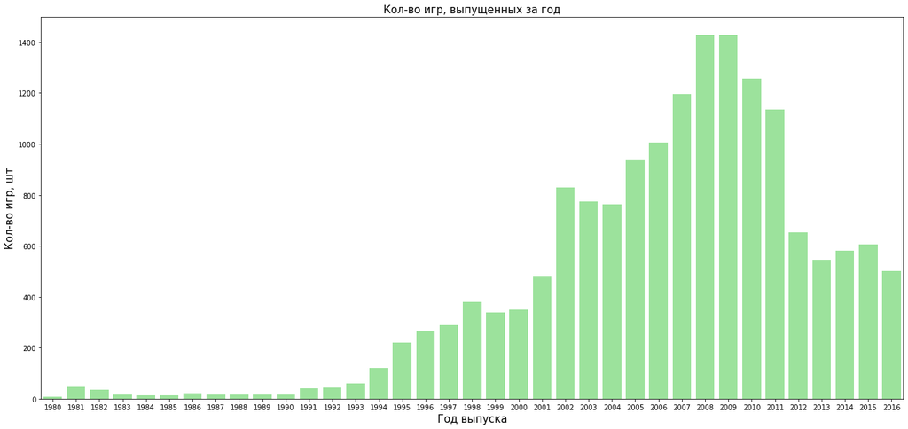

```python
# Группируем данные по выпущенным играм за каждый год
num_of_games = df.groupby('year_of_release', as_index=False)['name'].count()

# Строим по нему график
sns.barplot(data=num_of_games, x='year_of_release', y='name', color='lightgreen')

# Добавляем заголовок, подписи к осям и подходящий размер
plt.gcf().set_size_inches(22, 10)
plt.title('Кол-во игр, выпущенных за год', size=15)
plt.xlabel('Год выпуска', size=15)
plt.ylabel('Кол-во игр, шт', size=15);
```

Нам нужно провести еще ряд анализов и посмотреть на графики по ним, чтобы окончатльно решить какой период брать для прогнозирования.

Но на данном этапе, у меня уже складывается мнение, что нецелесообразно брать в дальнейший анализ данные старше последних `3-4 лет`, так как нам нужна релевантная информация для более правдоподобного прогнозирования на `2017 год`, ввиду того, что платформы и игры, которые были популярны `5-10 лет` назад, сейчас могут быть неактуальны и нерепрезентативны, поэтому, чтобы в этом убедиться, мы должны посмотреть на популярные платформы за все время, посмотреть на их жизненный цикл и уже отталкиваясь от этого выбрать актуальную для нас выборку.

## Изменение продаж по платформам

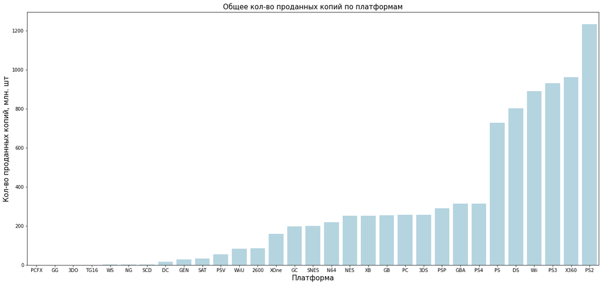

```python
# Группируем данные по платформам и их суммарным продажам
sum_of_platform = df.groupby('platform', as_index=False)['total_sales'].sum().sort_values(by='total_sales')

# Строим график
sns.barplot(data=sum_of_platform, x='platform', y='total_sales', color='lightblue')

# Добавляем заголовок, подписи к осям и подходящий размер
plt.gcf().set_size_inches(22, 10)
plt.title('Общее кол-во проданных копий по платформам', size=15)
plt.xlabel('Платформа', size=15)
plt.ylabel('Кол-во проданных копий, млн. шт', size=15);
```

**Вывод:** Мы видим, что `PS2` является платформой с самым большим количеством проданных копий игр, далее идут `X360`, `PS3`, `Wii`, `DS`, `PS` и затем уже вдвое (и более) меньше другие платформы (относительно новые, либо слишком старые, которые не просуществовали длительный период)

Оставим 5 платформ с наибольшим количеством проданных игр и посмотрим сколько в среднем 'живет' одна платформа

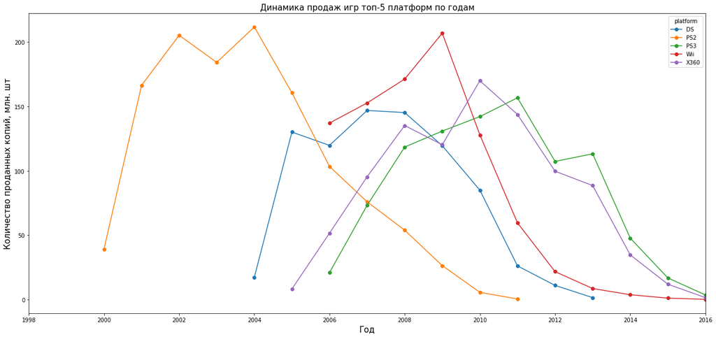

```python
# Создадим список из 5 платформ с наибольшим количеством проданных игр
top5_lst = list(sum_of_platform.sort_values('total_sales',ascending=False).head()['platform'].unique())

# Отфильтруем дф по этим платформам и запишем в переменную сводную по ней
top5_platforms = df.query('platform in @top5_lst').pivot_table \
(index='year_of_release', columns='platform',values='total_sales',aggfunc='sum')

# Создадим график с необходимыми настройками
fig, ax = plt.subplots()
top5_platforms.plot(kind='line', figsize=(22,10), ax=ax, style ='o-');
ax.set_title('Динамика продаж игр топ-5 платформ по годам', size=15)
ax.set_xlabel('Год', size=15)
ax.set_ylabel('Количество проданных копий, млн. шт', size=15)
ax.set_xlim([1998, 2016]);
```

**Вывод:** из данного графика, мы можем сделать вывод, что в среднем 'продолжительность жизни' платформы достигает `≈ 7-10 лет`. Например, самая топовая платформа по продажам `PS2` 'изжила' себя примерно в `2011 году`, а `DS` в `2013 году`,что еще раз подтверждает мою гипотезу о том, что нам нужны более свежие данные для более точного прогноза.

## Лидирующие платформы по продажам

```python
# Для начала создадим перемннную и отсортируем данные, которую теперь будут использоваться в дальнейших расчетах
df_n = df[df['year_of_release'] >= 2013]
```

```python
# Посмотрим на новый топ платформ по продажам игр
df_n.groupby('platform', as_index=False)['total_sales'].sum().sort_values(by='total_sales',ascending=False)
```

|  | platform | total_sales |
| --- | --- | --- |
| 4 | PS4 | 314.14 |
| 3 | PS3 | 181.43 |
| 10 | XOne | 159.32 |
| 0 | 3DS | 143.25 |
| 9 | X360 | 136.80 |
| 8 | WiiU | 64.63 |
| 2 | PC | 39.43 |
| 6 | PSV | 32.99 |
| 7 | Wii | 13.66 |
| 5 | PSP | 3.50 |
| 1 | DS | 1.54 |

**Вывод:** мы видим, что за выбранный нами период лидерами стали новые платформы. `PS4` имеет больше всего проданных игр, далее идет прошлое поколение - `PS3`, `XOne`, `3DS` и замыкает первую пятерку `X360`.

Как и ожидалось, в лидеры вышли новые платформы, в то время как в конце находятся старые платформы, пик продаж которых приходился на более ранний период.

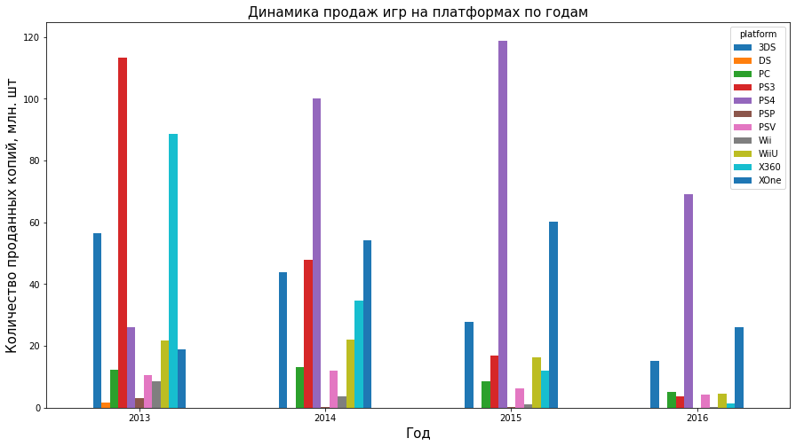

```python
# Отфильтруем дф по этим платформам и запишем в переменную сводную по ней
df_n_pivot = df_n.pivot_table \
(index='year_of_release', columns='platform',values='total_sales',aggfunc='sum')

# Создадим график с необходимыми настройками
fig, ax = plt.subplots()
df_n_pivot.plot(kind='bar', figsize=(15,8), ax=ax, style ='o-', rot=0)
ax.set_title('Динамика продаж игр на платформах по годам', size=15)
ax.set_xlabel('Год', size=15)
ax.set_ylabel('Количество проданных копий, млн. шт', size=15);
```

**Вывод:** для наглядности построили график, где отчетливо видна тенденция к росту продаж игр на новых платформах.

- еще в 2013 году лидером оставался `PS3`, а уже в 2014 его обогнал старший представитель - `PS4`;
- точно такая же картина с `X360` и `XOne` и другими платформами;
- мы наблюдаем как удачно сменяется старое поколение платформ их новыми обновленными версиями, и как доля старых платформ из года в год уменьшается на рынке игровой индустрии

Далее построим ящик с усами, для анализа глобальных продаж по платформам

```python
#Построим график с усами, оставив только потенциально прибыльные платформы
def col_boxplot(data,col,lim=1):
    plt.figure(figsize=(14,8), dpi=70)
    sns.boxplot(x=col, y='total_sales', data=data,palette="Set3")
    plt.ylabel('Суммарные продажи')
    if col=='platform':
        plt.title('Продажи по платформ')
        plt.xlabel('Платформа')
    else:
        plt.title('Продажи по жанрам')
        plt.xlabel('Жанр')
    if lim==0:
        plt.ylim();
    else:
        plt.ylim([0, 4]);
```

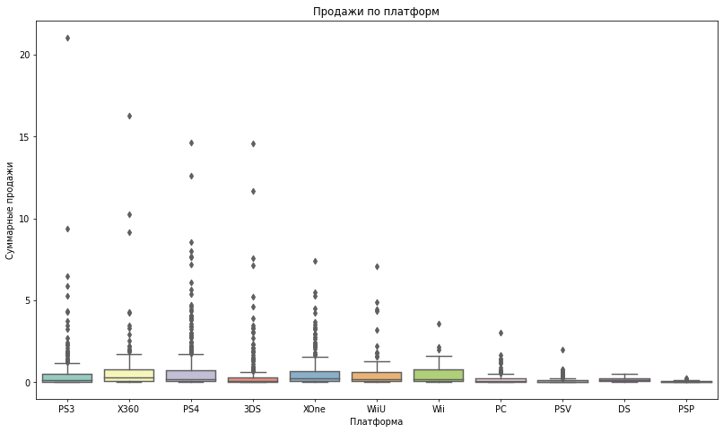

```python
# Строим график без масштабирования
col_boxplot(df_n,'platform',0)
```

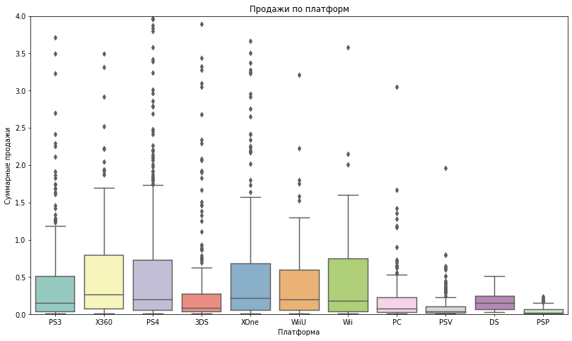

```python
# Строим график с масштабированием
col_boxplot(df_n,'platform')
```

**Вывод:** Исходя из графиков, мы видим, что:

- Медианное значение у топ-5 платформ (`X360`, `Wii`, `PS4`, `XOne`, `WiiU`) в районе `0.2-0.3 млн.` проданных копий и продаж по ним в целом больше, чем у оставшихся.
- У оставшихся платформ она ниже, и в целом, продажи уступают, это можно объяснить большей доступностью и оптимизацией выпускаемой продукции для топ-5 платформ,в то время, как на том же `PC` не всегда хватит мощности компьютера для возможности играть в самые новые актуальные продукты, соотвестенно это ведет к снижению продаж, или же `PSV` и `PSP` , который является нишевым продуктом, имеющий низкую автономность и удобство управления для среднестатистического геймера.

## Влияние отзывов пользователей и критиков на продажи внутри платформы

Для нахождения корреляции между отзывами пользователей и критиков и продажи внутри одной платформы, мы возьмем `PS4`, так как из расчетов выше мы выяснили, что на нем было продано больше всего копий игр и поэтому его можно отнести к 'популярной платформе'

```python
# Оставим значения без замененных пропусков в предобработке для более точного результата
df_сscore = df_n.query('critic_score != -1')[['platform','total_sales','critic_score']]
df_uscore = df_n.query('user_score != -1')[['platform','total_sales','user_score']]
```

```python
# Создадим функцию, которая на вход принимает наименование платформы и на его основе, фильтрует датафрейм, по которому далее
# строятся 2 графика рассеяния с оценкой критиков и пользлвателей с определенными параметрами, считается корреляция между
# оценокой критиков/пользователей и продажами и на основании полученного рез-та говорится о степени взаимосвязи
def platform_scatter(name):


    #фильтруем датафрейм по нужной платформе
    platform_c = df_сscore[df_сscore['platform']== name]
    platform_u = df_uscore[df_uscore['platform']== name]

    # Настраиваем и рисуем 2 графика рассеяния по оценкам критиков и пользователей
    fig, ax = plt.subplots(1 ,2, figsize=(15,5))
    sns.scatterplot(x='user_score', y='total_sales', data=platform_u, ax=ax[0], alpha=0.45)
    sns.scatterplot(x='critic_score', y='total_sales', data=platform_c, ax=ax[1], alpha=0.45)
    ax[0].set(title= f'Корреляция между продажами и оценками пользователей на {name}')
    ax[0].title.set_size(12)
    ax[1].set(title= f'Корреляция между продажами и оценками критиков на {name}')
    ax[1].title.set_size(12)
    ax[0].set(xlabel='Оценки пользователей')
    ax[1].set(xlabel='Оценки критиков')
    ax[0].set(ylabel='Количество проданных копий')
    ax[1].set(ylabel='Количество проданных копий')
    plt.show()

    #Считаем корреляцию между оценками пользователей и продажами
    user_corr = platform_u['user_score'].corr(platform_u['total_sales'])

    # На основании полученного рез-та делаем вывод о степени взаимосвязи
    if user_corr <= 0.3:
        print (f'Корреляция между продажами и оценкой пользователей {name} очень cлабая: {round(user_corr,3)}')
    elif 0.3 < user_corr <= 0.5:
        print (f'Корреляция между продажами и оценкой пользователей {name} cлабая: {round(user_corr,3)}')
    elif 0.5 < user_corr <= 0.7:
        print (f'Корреляция между продажами и оценкой пользователей {name} cредняя: {round(user_corr,3)}')
    elif 0.7 < user_corr <= 0.9:
        print (f'Корреляция между продажами и оценкой пользователей {name} высокая: {round(user_corr,3)}')
    elif np.isnan(user_corr) == True:
        print('Отсуствуют (или недостаточно для оценки) данных по отзывам пользователей на данной платформе')
    else:
        print(f'Корреляция между продажами и оценкой пользователей {name} очень высокая: {round(user_corr,3)}')

    # Проделываем те же действия только уже для оценок критиков
    critic_corr = platform_c['critic_score'].corr(platform_c['total_sales'])

    if critic_corr <= 0.3:
        print (f'Корреляция между продажами и оценкой критиков {name} очень cлабая: {round(critic_corr,3)}')
    elif 0.3 < critic_corr <= 0.5:
        print (f'Корреляция между продажами и оценкой критиков {name} cлабая: {round(critic_corr,3)}')
    elif 0.5 < critic_corr <= 0.7:
        print (f'Корреляция между продажами и оценкой критиков {name} cредняя: {round(critic_corr,3)}')
    elif 0.7 < critic_corr <= 0.9:
        print (f'Корреляция между продажами и оценкой критиков {name} высокая: {round(critic_corr,3)}')
    elif np.isnan(critic_corr) == True:
        print('Отсуствуют (или недостаточно для оценки) данных по отзывам критиков на данной платформе')
    else:
        print(f'Корреляция между продажами и оценкой критиков {name} очень высокая: {round(critic_corr,3)}')

    idx = ['total_sales', 'user_score', 'critic_score']
    df = pd.DataFrame({'total_sales':[1,round(user_corr,3),round(critic_corr,3)]}, index = idx)

    plt.figure(figsize=(3,3), dpi= 80)
    g = sns.heatmap(df, cmap ='Greens', linewidths = 0.30, annot = True,yticklabels=idx)
    g.set_yticklabels(g.get_yticklabels(), rotation = 0)
    plt.title(f'Взаимосвязь между общими продажами и оценками платформы {name}', size = 12)
    plt.show();
```

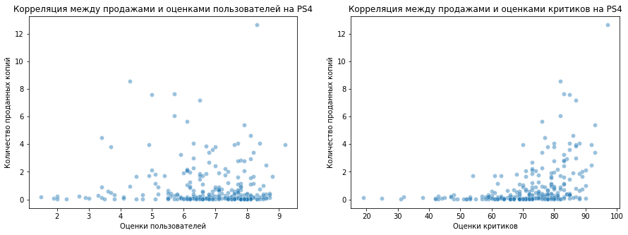

```
Корреляция между продажами и оценкой пользователей PS4 очень cлабая: -0.032
Корреляция между продажами и оценкой критиков PS4 cлабая: 0.407
```

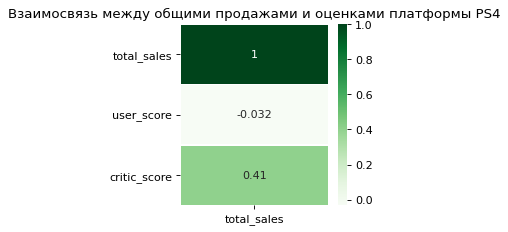

```python
# Применим наши функции для PS4
platform_scatter('PS4')
```

Видим, что взаимосвязь слабая, однако, можем заметить, что критиков слушают чаще, чем пользователей.

Теперь можем применить наши функции для анализа оставшихся потеницально прибыльных платформ, которые мы выделили раннее

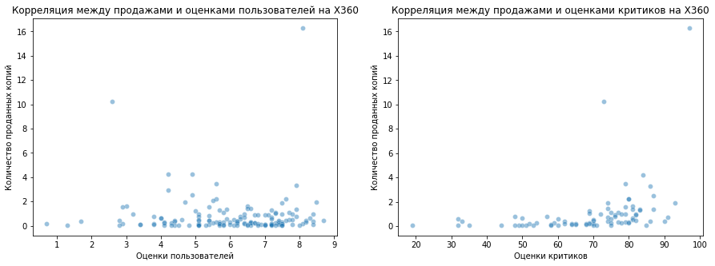

```
Корреляция между продажами и оценкой пользователей X360 очень cлабая: -0.012
Корреляция между продажами и оценкой критиков X360 cлабая: 0.35
```

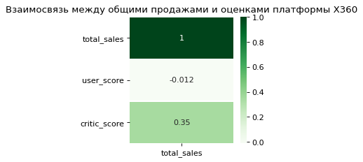

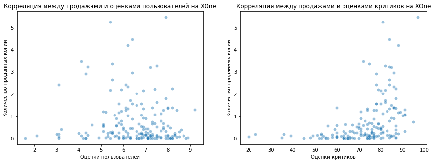

```
Корреляция между продажами и оценкой пользователей XOne очень cлабая: -0.069
Корреляция между продажами и оценкой критиков XOne cлабая: 0.417
```

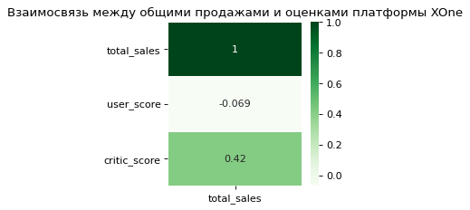

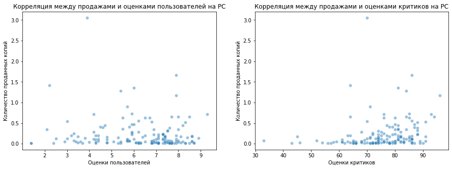

```
Корреляция между продажами и оценкой пользователей PC очень cлабая: -0.094
Корреляция между продажами и оценкой критиков PC очень cлабая: 0.196
```

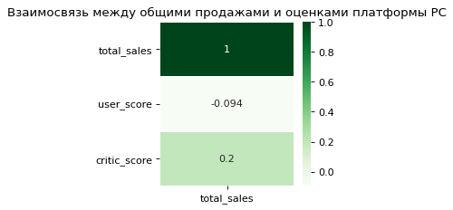

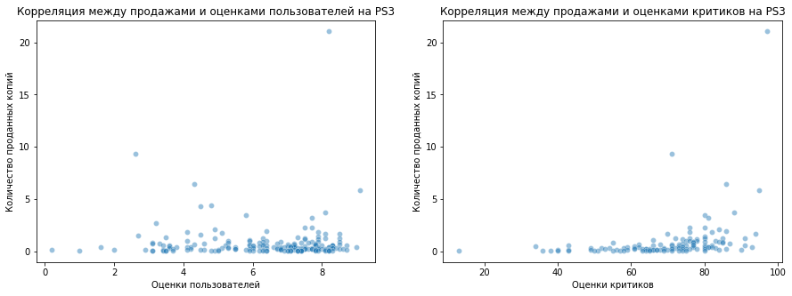

```
Корреляция между продажами и оценкой пользователей PS3 очень cлабая: 0.002
Корреляция между продажами и оценкой критиков PS3 cлабая: 0.334
```

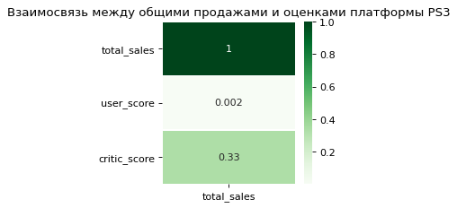

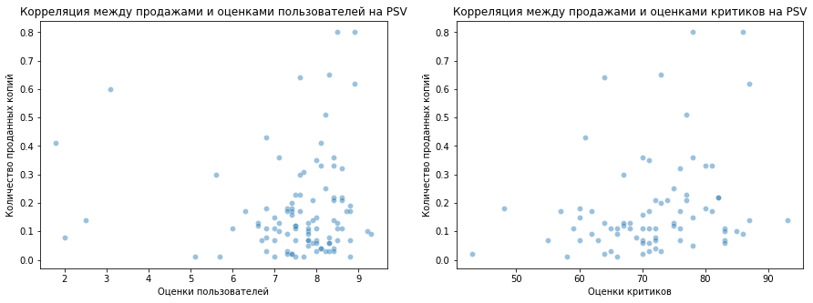

```
Корреляция между продажами и оценкой пользователей PSV очень cлабая: 0.001
Корреляция между продажами и оценкой критиков PSV очень cлабая: 0.255
```

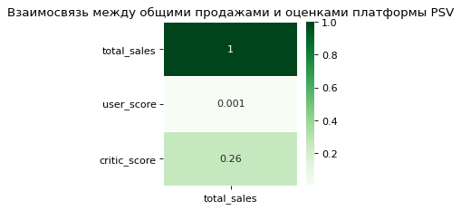

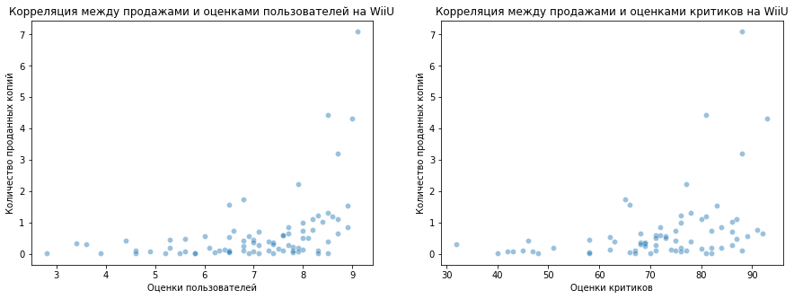

```
Корреляция между продажами и оценкой пользователей WiiU cлабая: 0.419
Корреляция между продажами и оценкой критиков WiiU cлабая: 0.376
```

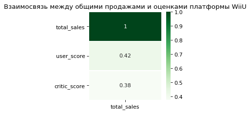

[8 more figures not shown]

```python
# Создадим цикл, который переберет каждую платформу и поочередно построит график рассеяния и хитмап для каждой из них
for name in ['X360', 'XOne', 'PC','PS3','PSV','WiiU','3DS','Wii','PSP', 'DS']:
    platform_scatter(name)
    # для удобства, графики каждой новой платформы отделим знаком '-'
    print('-'*120)
```

**Вывод:** исходя из полученных графиков и посчитав корреляцию, мы можем сделать вывод, что оценки критиков и пользователей играют не самую важную роль, от которой зависят продажи игр на той или иной платформе, но в среднем, к критикам прислушиваются чаще, чем к пользователям.

## Распределение игр по жанрам

```python
# Создадим отдельную перменную, куда поместим данные по жанрам,кол-ву выпущенных игр в нем и общей сумме продаж
df_genre = df_n.groupby('genre',as_index=False).agg({'name': 'count', 'total_sales': 'median'})

# Для удобства переименуем столбцы
df_genre.columns = ['genre','games_count','total_sales']
```

```python
# Созадим функцию, которая принимает в аргумент столбец по которому будет фильтроваться дф и строить график по заданным параметрам
def genre_bar(value):

    # Отфильтруем и создадим график с необходимыми настройками
    if value=='total_sales':
        ax = df_genre.sort_values(by=value).plot(x='genre',y=value,kind='bar', \
                                            figsize=(15,8), rot=0, ec='black',color='lightgreen')
    else:
        ax = df_genre.sort_values(by=value).plot(x='genre',y=value,kind='bar', \
                                            figsize=(15,8), rot=0, ec='black',color='lightblue')
      # Добавляем подписи к каждому столбцу
    for p in ax.patches:
        height = p.get_height()
        ax.text(p.get_x()+p.get_width()/2,
                height + 0,
                '{:.2f}'.format(height),
                fontsize=10,
                ha="center")

    # Подписываем оси и заголовок
    if value=='total_sales':
        plt.title('Распределение проданных копий игр по жанрам', size=15)
        plt.xlabel('Жанр', size=15)
        plt.ylabel('Медианные продажи, млн. шт', size=15);
    else:
        plt.title('Количество выпущенных игр в жанре', size=15)
        plt.xlabel('Жанр', size=15)
        plt.ylabel('Количество игр, шт', size=15);
```

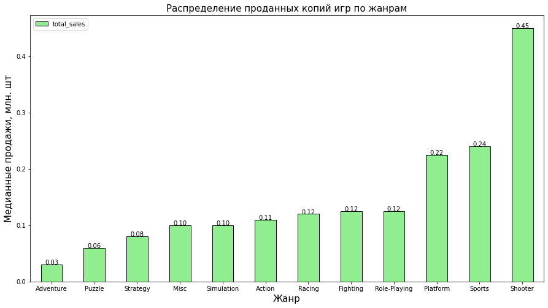

```python
# Строим график распределений продаж по жанрам
genre_bar('total_sales')
```

**Вывод:** мы видим, что самым продаваемым жанром является `Shooter` с медианным значение - `0.45 млн` проданных копий игр, далее идет - `Sports` c `0.24 млн` медианных продаж, с небольшим отрывом уступает еме `Platform` - `0.22 млн` копий и практически одинаковые медианные продажи у оставшихся жанров, кроме `Puzzle` и `Adventure` с `0.06 млн` и `0.03 млн` проданных копий соотвественно.

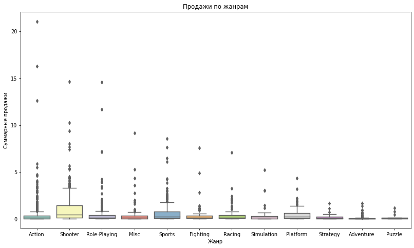

```python
# Построим ящик с усами сначала без масштабирования, а потом с ним
col_boxplot(df_n,'genre',0)
```

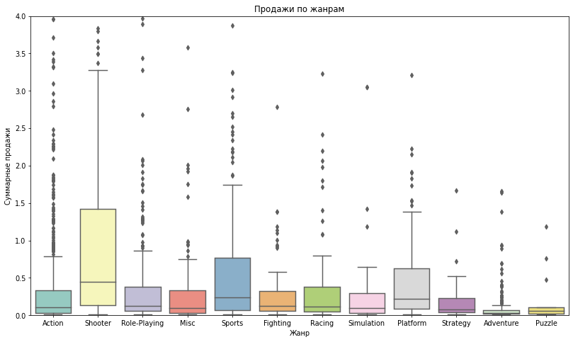

```python
col_boxplot(df_n,'genre')
```

**Вывод:**

- Можем заметить, что жанр `Action` имеет самое большое количество продаж, но заметно меньшее медианное значние по сравнению с другими топовыми жанрами по этому же показателю. Скорее всего, это связано с тем, что основные продажи этому жанру приносило совсем небольшой количество игр;
- Жанр `Shooter` очень хорошо себя показывает как и по продажам в принципе, так и по его медианным значениям, скорее всего, пользователям действительно нравится этот жанр;
- Можем заметить, что жанр `Adventure` и `Puzzle` в целом полуьзуется малой популярностью, судя по их продажам.

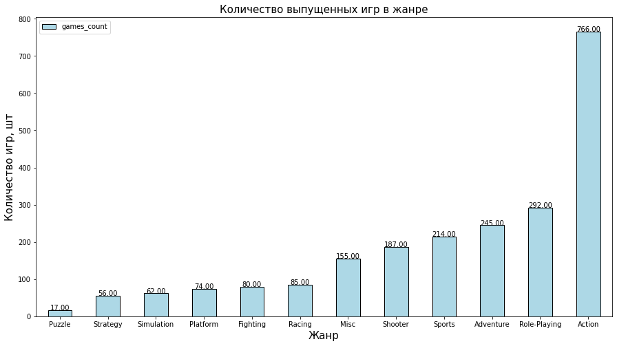

```python
# Строим график жанров в разрезе количества выпущенных для них игр
genre_bar('games_count')
```

# Портрет пользователя отдельного региона

## Самые популярные платформы в регионе

Для начала создадим несколько функций, которые облегчат нам построение графиков для ответа на поставленные вопросы

```python
# Создадим функцию для "расшифровки" аббревиатур в столбце 'rating'. На вход будет приниматься значение из столбца и при совпадении
# заменять на нужное нам.
def rating_cat(col):

    # Сравниваем каждое значение и присваиваем "расшифрованный" вариант
    if col == 'M':
        return 'от 17 лет'
    elif col == 'T':
        return '13-19 лет'
    elif col == 'E':
        return 'Для всех'
    elif col == 'E10+':
        return 'от 10 лет'
    else:
        return 'Unknown'
```

```python
# Создадим новый столбец с "расшифрованными" значениями, применив нашу функцию
df_n['rating_n'] = df_n['rating'].apply(rating_cat)
```

```python
# Создадим функцию, которая на вход принимает наименования столбца, региона и номера для корректного вывода графика.
# Функция строит сводную таблицу по заданному исследуемому параметру и считает общую сумму в конкретном регионе, оставляяя
# топ-5 наибольших значений и строит по каждому отдельному региону график
def region_barplot(col,region,ax):

    # Создаем сводную таблицу, по которой будет строиться график
    reg_pivot = df_n.groupby(col).agg({region: 'sum'}).sort_values(by=region, ascending=False).head()

    # Создаем два словаря для настройки графиков в зависомости от региона
    dict_of_titles = {'na_sales': 'Америка', 'eu_sales': 'Европа', 'jp_sales': 'Япония'}
    dict_of_colors = {'na_sales': 'lightblue', 'eu_sales': 'yellow', 'jp_sales': 'lightgreen'}

    #Строим график,с необходимыми параметрами
    ax = reg_pivot.plot(kind='bar', title=dict_of_titles[region], ax=axes[ax],
                   fontsize=12, color=dict_of_colors[region], ec='black', rot=0)

    # Подписываем каждый столбик
    for p in ax.patches:
        height = p.get_height()
        ax.text(p.get_x()+p.get_width()/2,
            height + 0.55,
            '{:.2f}'.format(height),
            fontsize=10,
            ha="center")

    # Добавляем дополнительные настройки
    ax.set_xlabel('')
    ax.title.set_size(15)
```

```python
# Создаем еще одну функцию, которая на основе прошлой будет строить сразу все 3 графика  по исследуемому параметру каждого региона
def final_plot(col):

    # Создадим список с необходимыми значениями, которые будут перебираться в цикле для построения графиков из прошлой функции
    reg_list = ['na_sales','eu_sales','jp_sales']

    # Создадим цикл, который перебирает каждое значение из списка, подставляет это значение в аргумент прошлой функции и
    # строит по ним 3 нужных графика для каждого региона
    for i in reg_list:
        region_barplot(col,i,reg_list.index(i))
```

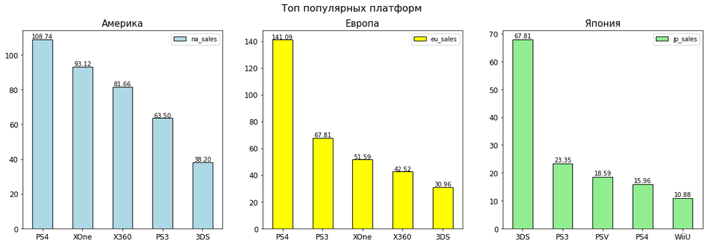

```python
# Строим графики по самым популярным платформам в регионе
fig, axes = plt.subplots(1, 3, figsize=(20,6))
fig.suptitle('Топ популярных платформ', fontsize=16)
final_plot('platform')
```

**Вывод:**

Самыми популярые игровые платформы:

- *Америка*: `PS4` со `108.74 млн` проданных копий игр, `XOne` с `93.12 млн` и замыкает тройку `X360` - `81.66 млн`.
- *Европа*: `PS4` со `141.09 млн` проданных копий игр, `PS3` с `67.81 млн` и замыкает тройку `XOne` - `51.59 млн`.
- *Япония*: `3DS` со `67.81 млн` проданных копий игр, `PS3` с `23.35 млн` и замыкает тройку `PSV` - `18.59 млн`.

Наименешьей популярностью среди платформ в Америке и Европе пользуется `3DS`, в то время как в Японии наоборот данная платформа является лидером, но при этом `WiiU` уступает другим платформам из списка

## Самые популярные жанры в регионе

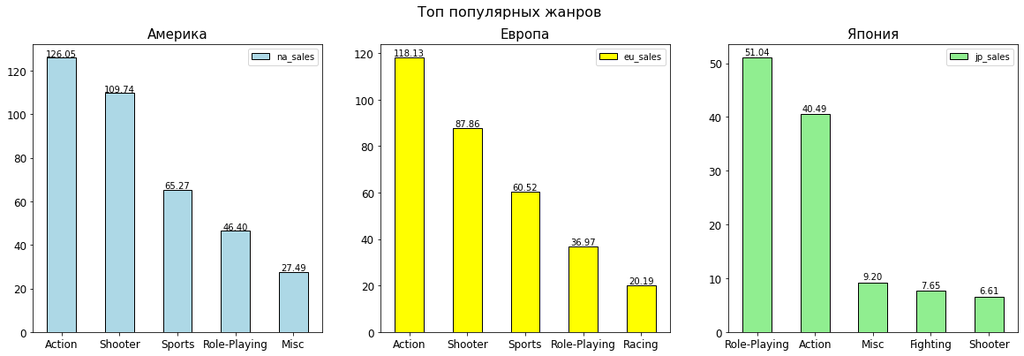

```python
# Строим графики по самым популярным жанрам в регионе
fig, axes = plt.subplots(1, 3, figsize=(20,6))
fig.suptitle('Топ популярных жанров', fontsize=16)
final_plot('genre')
```

**Вывод:**

Самые популярные игровые жанры:

- В Америке и Европе вкусы практически идентичны первые 4 места делят одинаковые жанры, больше всего было продано `Action` и `Shooter` более `100 млн` в Америке и свыше `80 млн` в Европе.
- В Японии ровно обратная картина, лидером является `Role-Playing` с более чем `50 млн` копий, это можно объяснить тем, что в Японии помимо стандартного во всем мире жанра РПГ, развит свой собственный, так называемый `JRPG` (Японская ролевая игра), которая пользуется большей популярностью в стране, по этой причине, так же видим жанр `Fighting`, можно предположить, что он находится в лидерах, т.к многие игры-файтинги выпускались в Японии и даже по мотивам `Аниме` (японская мультипликация).

При этом японцы как и европейцы и американцы любят поиграть в шутеры и экшен жанры.

```python
def region_pie(col,region,ax):
    # Создаем два словаря для настройки графиков в зависомости от региона
    dict_of_titles = {'na_sales': 'Америка', 'eu_sales': 'Европа', 'jp_sales': 'Япония'}
    if col in ['platform','genre']:
        data = df_n.groupby(col,as_index=False).agg({region: 'sum'}).sort_values(by=region, ascending=False)
        data.loc[data[region] < data.iloc[4][region],col] = 'others'
        data = data.groupby(col,as_index=False)[region].sum()
        data.plot(y=region, kind='pie', labels=data[col], autopct='%.2f%%', ax=axes[ax], legend=False, title=dict_of_titles[region], ylabel='');
    else:
        data = df_n.groupby(col,as_index=False).agg({region: 'sum'}).sort_values(by=region, ascending=False)
        data.plot(y=region, kind='pie', labels=data[col], autopct='%.2f%%', ax=axes[ax], legend=False, title=dict_of_titles[region], ylabel='');
```

```python
# Создаем еще одну функцию, которая на основе прошлой будет строить сразу все 3 графика  по исследуемому параметру каждого региона
def final_pie(col):

    # Создадим список с необходимыми значениями, которые будут перебираться в цикле для построения графиков из прошлой функции
    reg_list = ['na_sales','eu_sales','jp_sales']

    # Создадим цикл, который перебирает каждое значение из списка, подставляет это значение в аргумент прошлой функции и
    # строит по ним 3 нужных графика для каждого региона
    for i in reg_list:
        region_pie(col,i,reg_list.index(i))
```

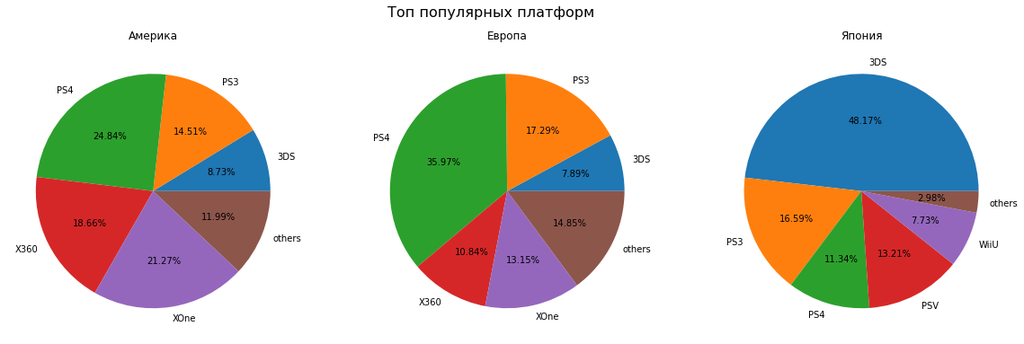

```python
fig, axes = plt.subplots(1, 3, figsize=(20,6))
fig.suptitle('Топ популярных платформ', fontsize=16)
final_pie('platform')
```

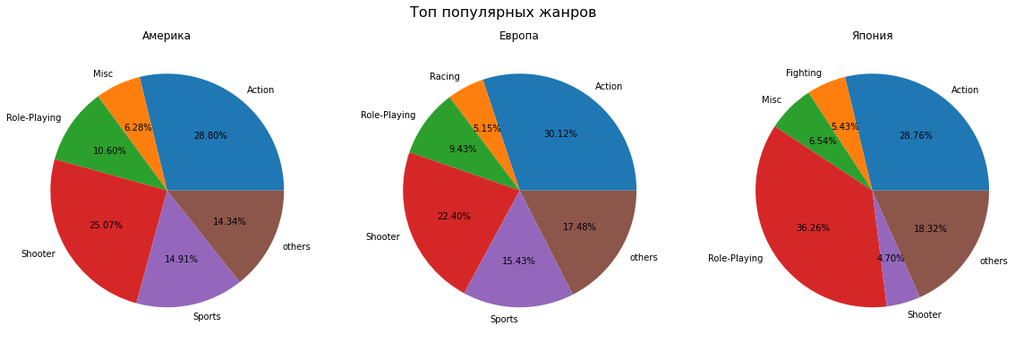

```python
fig, axes = plt.subplots(1, 3, figsize=(20,6))
fig.suptitle('Топ популярных жанров', fontsize=16)
final_pie('genre')
```

**Вывод:** особо к вышесказанному мной добавить нечего, рассмотрели так же топ платформ и жанров, но только уже в долях от общих продаж в регионах